# Classification of Punishment

George Dewey

2022-12-19

# Classifying punishment into subtypes

We classify punishment into 3 main subtypes:

- inequality aversion: punishment to reduce perceived inequality
  - 3rd party punishment is a subclass of this: punishment to promote cooperation that is not reactive
- reactive: punishment in response to other punishment
- unexplained: punishment that is neither reactive nor inequality aversion

### Experiment 1 data

```r
# 4 main datasets:
# harmdata - cleaned raw individual-level data
# ldata4 - tie component of network-level data
# ndata1 - node component of network-level data
# data1 - main aggregated dataset including lag (rounds t-1, t-2, etc.) data


mean1 = function(x) {mean(x,na.rm=TRUE)}
median1 = function(x) {median(x, na.rm = TRUE)}

# harmdata
load("~/Documents/Projects/harming_esn/Data/exp1/harmdata.Rdata") #harmdata

# ldata4
load("~/Documents/Projects/harming_esn/Data/exp1/ldata4_0316X.Rdata")

# ndata1
load("~/Documents/Projects/harming_esn/Data/exp1/ndata_individual.Rdata")

# data1
load("~/Documents/Projects/harming_esn/Data/exp1/data1.Rdata") #data1

data1 = data1 %>%
  as_tibble()

dim(data1 %>% filter(behavior_punish == 1)) #562 punishments
```

```
## [1] 562  61
```

#### Punishment for inequality aversion

We define this subtype of punishment as punishment that occurs when the wealth of the ego is less than the average wealth of alters.

```r
# first, get the list of alters
ndata_alters_list = ndata1 %>%
  select(round, game, starts_with("id")) %>%
  filter(round != 0) %>%
  mutate(across(starts_with("id"), ~100*game+parse_number(.))) %>%
  rename(superid = id)

names(ndata_alters_list)[4:20] = c("alter1", "alter2", "alter3", "alter4",
                                   "alter5", "alter6", "alter7", "alter8",
                                   "alter9", "alter10", "alter11", "alter12",
                                   "alter13", "alter14", "alter15", "alter16",
                                   "alter17")

current_wealth = data1 %>%
  filter(round != 0) %>%
  select(superid, game, round, cumulativePayoff, cPayoffS)

ndata_long_alters = ndata_alters_list %>%
  pivot_longer(cols = starts_with("alter"), values_to = ("alter_id")) %>%
  filter(is.na(alter_id) == 0)

ndata_long_alters_wealth = ndata_long_alters %>%
  left_join(current_wealth, by = c("round", "game", "alter_id" = "superid")) %>%
  group_by(superid, round, game) %>%
  summarize(mean_alter_wealth = mean1(cPayoffS))

data1_pc = data1 %>%
  left_join(ndata_long_alters_wealth, by = c("round", "game", "superid")) %>%
  mutate(wealth_inequal = ifelse(cPayoffS < mean_alter_wealth, 1, 0))

data1_pc %>%
  filter(behavior_punish == 1, round > 0) %>%
  group_by(wealth_inequal) %>%
  summarize(n = n()) %>%
  mutate(perc = n/sum(n)) %>%
  filter(is.na(wealth_inequal) == 0)
```

```
## # A tibble: 2 × 3
##   wealth_inequal     n  perc
##            <dbl> <int> <dbl>
## 1              0   270 0.480
## 2              1   279 0.496
```

```r
prop.test(x = c(270, 279), n = c(549, 549))
```

```
##
##  2-sample test for equality of proportions with continuity correction
##
## data:  c(270, 279) out of c(549, 549)
## X-squared = 0.23315, df = 1, p-value = 0.6292
## alternative hypothesis: two.sided
## 95 percent confidence interval:
##  -0.07735592  0.04456904
## sample estimates:
##    prop 1    prop 2
## 0.4918033 0.5081967
```

**49.6% wealth inequality vs 48% not due to wealth inequality**

#### Reactive punishment

Punishment in response to punishment, defined as punishment after an alter punished in last round regardless of punishing alters’ current ties (so this means the punishing alter no longer needs to be tied to the ego after rewiring).

```r
data1_pc =
  data1_pc %>%
  mutate(reactive_p = ifelse(behavior_punish == 1 & local_rate_punish_lag !=0, 1, 0))

data1_pc %>%
  filter(behavior_punish == 1) %>%
  mutate(reactive_p = ifelse(local_rate_punish_lag !=0, 1, 0)) %>%
  group_by(reactive_p) %>%
  summarize(n = n()) %>%
  mutate(perc = n/sum(n)) %>%
  filter(is.na(reactive_p) == 0)
```

```
## # A tibble: 2 × 3
##   reactive_p     n  perc
##        <dbl> <int> <dbl>
## 1          0   359 0.639
## 2          1   149 0.265
```

```r
prop.test(x = c(359, 149), n = c(508, 508))
```

```
##
##  2-sample test for equality of proportions with continuity correction
##
## data:  c(359, 149) out of c(508, 508)
## X-squared = 171.97, df = 1, p-value < 2.2e-16
## alternative hypothesis: two.sided
## 95 percent confidence interval:
##  0.3554277 0.4713440
## sample estimates:
##    prop 1    prop 2
## 0.7066929 0.2933071
```

**26.5% reactive, 63.9% not (54 NAs)**

#### Unexplained punishments

Punishment that is not reactive or calculated.

```r
data1_pc_punishes = data1_pc %>%
  filter(behavior_punish == 1)

data1_pc_punishes %>%
  filter(round <= 1) #49
```

```
## # A tibble: 49 × 64
##    superid round  game   age gender   country_3…¹ showS…² initi…³ payoff cumul…⁴
##      <dbl> <dbl> <int> <dbl> <chr>    <fct>         <dbl>   <dbl>  <dbl>   <dbl>
##  1     204     1     2    23 "male"   India             0     200    200     400
##  2     211     1     2    28 "female" Other             0    1150    100    1250
##  3     405     1     4    30 "male"   India             0     200    400     600
##  4     613     1     6    32 "male"   US                0     200    200     400
##  5     804     1     8    71 "female" US                0     200    100     300
##  6     809     1     8    NA ""       US                0    1150    100    1250
##  7     812     1     8    43 "male"   US                0    1150    300    1450
##  8    1305     1    13    32 "female" US                0    1150    200    1350
##  9    1401     1    14    45 "female" US                0     200      0     200
## 10    1404     1    14    31 "female" US                0     200      0     200
## # … with 39 more rows, 54 more variables: cPayoffS <dbl>, WealthLevel <chr>,
## #   behavior_coop <dbl>, behavior_defect <dbl>, behavior_punish <dbl>,
## #   local_rate_coop <dbl>, local_rate_defect <dbl>, local_rate_punish <dbl>,
## #   happ <dbl>, behaviorTime <dbl>, degree <dbl>, e_degree <dbl>,
## #   initial_coop <dbl>, initial_defect <dbl>, initial_punish <dbl>,
## #   initial_score_lag <dbl>, payoff_lag <dbl>, cumulativePayoff_lag <dbl>,
## #   cPayoffS_lag <dbl>, WealthLevel_lag <chr>, behavior_coop_lag <dbl>, …
## # ℹ Use `print(n = ...)` to see more rows, and `colnames()` to see all variable names
```

```r
data1_pc_punishes %>%
  filter(round > 1 & wealth_inequal == 0 & reactive_p == 0) #171
```

```
## # A tibble: 171 × 64
##    superid round  game   age gender   country_3…¹ showS…² initi…³ payoff cumul…⁴
##      <dbl> <dbl> <int> <dbl> <chr>    <fct>         <dbl>   <dbl>  <dbl>   <dbl>
##  1     204    13     2    23 "male"   India             0     200    300    2750
##  2     211     2     2    28 "female" Other             0    1150    200    1450
##  3     211     4     2    28 "female" Other             0    1150    100    1650
##  4     403     4     4    64 "male"   Other             0     200    600    1000
##  5     405     3     4    30 "male"   India             0     200    500    1150
##  6     405     5     4    30 "male"   India             0     200    800    2250
##  7     409    10     4    28 "male"   US                0    1150    100    2100
##  8     409     8     4    28 "male"   US                0    1150    400    2050
##  9     809     2     8    NA ""       US                0    1150    100    1350
## 10     809     5     8    NA ""       US                0    1150    300    1450
## # … with 161 more rows, 54 more variables: cPayoffS <dbl>, WealthLevel <chr>,
## #   behavior_coop <dbl>, behavior_defect <dbl>, behavior_punish <dbl>,
## #   local_rate_coop <dbl>, local_rate_defect <dbl>, local_rate_punish <dbl>,
## #   happ <dbl>, behaviorTime <dbl>, degree <dbl>, e_degree <dbl>,
## #   initial_coop <dbl>, initial_defect <dbl>, initial_punish <dbl>,
## #   initial_score_lag <dbl>, payoff_lag <dbl>, cumulativePayoff_lag <dbl>,
## #   cPayoffS_lag <dbl>, WealthLevel_lag <chr>, behavior_coop_lag <dbl>, …
## # ℹ Use `print(n = ...)` to see more rows, and `colnames()` to see all variable names
```

```r
# Cross tab
xtabs(~reactive_p + wealth_inequal, data1_pc_punishes)
```

```
##           wealth_inequal
## reactive_p   0   1
##          0 171 176
##          1  72  77
```

#### Calculating distribution of decision time by punishment status

##### Inequality aversion

```r
# Statistics
data1_pc %>%
  mutate(behaviorTime_sec = behaviorTime/1000) %>%
  group_by(wealth_inequal) %>%
  filter(is.na(wealth_inequal) == F) %>%
  summarize(mean_dt = mean1(behaviorTime_sec),
            median_dt = median1(behaviorTime_sec),
            max_dt = max(behaviorTime_sec, na.rm = T),
            min_dt = min(behaviorTime_sec, na.rm = T),
            range_dt = range(behaviorTime_sec, na.rm = T))
```

```
## # A tibble: 4 × 6
## # Groups:   wealth_inequal [2]
##   wealth_inequal mean_dt median_dt max_dt min_dt range_dt
##            <dbl>   <dbl>     <dbl>  <dbl>  <dbl>    <dbl>
## 1              0    7.69         4    106      1        1
## 2              0    7.69         4    106      1      106
## 3              1    8.03         5    102      1        1
## 4              1    8.03         5    102      1      102
```

```r
# Visual
pun1 = data1_pc %>%
  mutate(behaviorTime_sec = behaviorTime/1000) %>%
  na.omit() %>%
  filter(wealth_inequal %in% 0:1) %>%
  ggplot(aes(x = behaviorTime_sec, color = as.factor(wealth_inequal))) +
  geom_density(adjust = 2) +
  scale_x_log10(limits = c(1, 110),breaks = c(1, 10, 100)) +
  scale_y_continuous(limits = c(0, 1.3)) +
  scale_color_manual(labels = c("Inequality Aversion", "Other"),
                     values = c("orange", "skyblue2")) +
    theme(axis.title = element_blank(),
        axis.text = element_text(size = rel(1.3)),
        legend.position = "right") +
  guides(colour=guide_legend(title = NULL))
```

##### Reactive punishment

```r
# Statistics
data1_pc %>%
  mutate(behaviorTime_sec = behaviorTime/1000) %>%
  group_by(reactive_p) %>%
  filter(is.na(reactive_p) == F) %>%
  summarize(mean_dt = mean1(behaviorTime_sec),
            median_dt = median1(behaviorTime_sec),
            max_dt = max(behaviorTime_sec, na.rm = T),
            min_dt = min(behaviorTime_sec, na.rm = T),
            range_dt = range(behaviorTime_sec, na.rm = T))
```

```
## # A tibble: 4 × 6
## # Groups:   reactive_p [2]
##   reactive_p mean_dt median_dt max_dt min_dt range_dt
##        <dbl>   <dbl>     <dbl>  <dbl>  <dbl>    <dbl>
## 1          0    7.83         4    106      1        1
## 2          0    7.83         4    106      1      106
## 3          1    8.60         6     48      2        2
## 4          1    8.60         6     48      2       48
```

```r
# Visual
pun2 = data1_pc %>%
  mutate(behaviorTime_sec = behaviorTime/1000) %>%
  na.omit() %>%
  filter(reactive_p %in% 0:1) %>%
  ggplot(aes(x = behaviorTime_sec, color = as.factor(reactive_p))) +
  geom_density(adjust = 2) +
  scale_x_log10(limits = c(1, 110),breaks = c(1, 10, 100)) +
  scale_y_continuous(limits = c(0, 1.3)) +
  scale_color_manual(labels = c("Reactive Punishment", "Other"),
                     values = c("magenta", "skyblue2")) +
  theme(axis.title = element_blank(),
        axis.text = element_text(size = rel(1.3)),
        legend.position = "right") +
  guides(colour=guide_legend(title = NULL))
```

##### Unexplained punishment

```r
# Visual
pun3 = data1_pc %>%
  mutate(behaviorTime_sec = behaviorTime/1000,
         unexplained_p = ifelse(behavior_punish == 1 & reactive_p == 0 & wealth_inequal == 0, 1, 0)) %>%
  na.omit() %>%
  filter(unexplained_p %in% 0:1) %>%
  ggplot(aes(x = behaviorTime_sec, color = as.factor(unexplained_p))) +
  geom_density(adjust = 2) +
  scale_x_log10(limits = c(1, 110),breaks = c(1, 10, 100)) +
  scale_y_continuous(limits = c(0, 1.3)) +
  scale_color_manual(labels = c("Unexplained Punishment", "Other"),
                     values = c("darkgreen", "skyblue2")) +
    theme(axis.title = element_blank(),
        axis.text = element_text(size = rel(1.3)),
        legend.position = "right") +
  guides(colour=guide_legend(title = NULL))
```

#### Combined figure

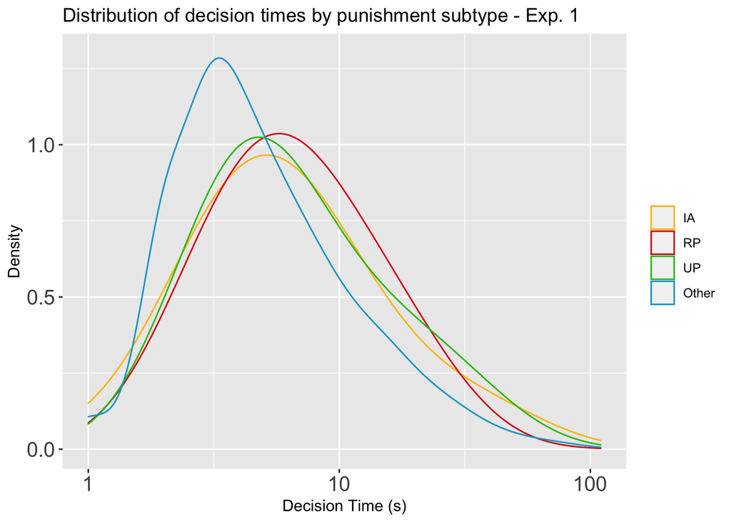

```r
# Create a 4-level variable: 1 = IA, 2 = Reactive, 3 = Unexpl., 4 = Other
data1_pc = data1_pc %>%
  mutate(
    behaviorTime_sec = behaviorTime/1000,
    unexplained_p = ifelse(behavior_punish == 1 & reactive_p == 0 &
                             wealth_inequal == 0, 1, 0),
    pun_type = case_when(behavior_punish == 1 & wealth_inequal == 1 ~ 1,
                         behavior_punish == 1 & reactive_p == 1 ~ 2,
                         behavior_punish == 1 & unexplained_p == 1 ~ 3,
                         TRUE ~ 4))

# save the final data_pc
# save(data1_pc, file = "~/Documents/Projects/harming_esn/code/exp1/data1_pc.Rdata")

# Combined fig. - exp 1
data1_pc %>%
  na.omit() %>%
  ggplot(aes(x = behaviorTime_sec, color = as.factor(pun_type))) +
  geom_density(adjust = 2) +
  scale_x_log10(limits = c(1, 110),breaks = c(1, 10, 100)) +
  scale_y_continuous(limits = c(0, 1.3)) +
  scale_color_manual(labels = c("IA", "RP", "UP", "Other"),
                     values = c("#FFBF00", "#DE1A1A", "#29BF12", "#00A5CF")) +
    theme(
        axis.text = element_text(size = rel(1.3)),
        legend.position = "right") +
  guides(colour=guide_legend(title = NULL))+
  xlab("Decision Time (s)") +
  ylab("Density") +
  ggtitle("Distribution of decision times by punishment subtype - Exp. 1")
```

### Experiment 2 data

```r
load("~/Documents/Projects/harming_esn/data/exp2/ndata1_tp.Rdata")
load("~/Documents/Projects/harming_esn/data/exp2/ldata4_tp.Rdata")
load("~/Documents/Projects/harming_esn/data/exp2/tpdata.Rdata")

tpdata = tpdata %>%
  as_tibble()

tpdata %>%
  filter(behavior == "P") %>%
  dim() #612 punishments
```

```
## [1] 612  55
```

#### Instrumental punishment: punishing to reduce inequality defined as punishment that occurs when ego’s wealth is lower than the mean wealth of alters

```r
# first, get the list of alters
ndata_alters_list = ndata_tp %>%
  select(round, game, starts_with("id")) %>%
  filter(round != 0) %>%
  mutate(across(starts_with("id"), ~100*game+parse_number(.))) %>%
  rename(superid = id)

length(names(ndata_alters_list))
```

```
## [1] 17
```

```r
names(ndata_alters_list)[4:17] = c("alter1", "alter2", "alter3", "alter4",
                                   "alter5", "alter6", "alter7", "alter8",
                                   "alter9", "alter10", "alter11", "alter12",
                                   "alter13", "alter14")

current_wealth = tpdata %>%
  filter(round != 0) %>%
  select(superid, game, round, cumulativePayoff, cPayoffS)

ndata_long_alters = ndata_alters_list %>%
  pivot_longer(cols = starts_with("alter"), values_to = ("alter_id")) %>%
  filter(is.na(alter_id) == 0)

ndata_long_alters_wealth = ndata_long_alters %>%
  left_join(current_wealth, by = c("round", "game", "alter_id" = "superid")) %>%
  group_by(superid, round, game) %>%
  summarize(mean_alter_wealth = mean1(cPayoffS))
tpdata_pc = tpdata %>%
  left_join(ndata_long_alters_wealth, by = c("round", "game", "superid")) %>%
  mutate(wealth_inequal = ifelse(cPayoffS < mean_alter_wealth, 1, 0))

tpdata_pc %>%
  filter(behavior=="P", round > 0,is.na(wealth_inequal) == 0) %>%
  group_by(wealth_inequal) %>%
  summarize(n = n()) %>%
  mutate(perc = n/sum(n))
```

```
## # A tibble: 2 × 3
##   wealth_inequal     n  perc
##            <dbl> <int> <dbl>
## 1              0   290 0.482
## 2              1   312 0.518
```

```r
# checking p-value
prop.test(x = c(290, 312), n = c(290+312,  290+312))
```

```
##
##  2-sample test for equality of proportions with continuity correction
##
## data:  c(290, 312) out of c(290 + 312, 290 + 312)
## X-squared = 1.4651, df = 1, p-value = 0.2261
## alternative hypothesis: two.sided
## 95 percent confidence interval:
##  -0.09465347  0.02156377
## sample estimates:
##    prop 1    prop 2
## 0.4817276 0.5182724
```

#### Reactive punishment: punishment in response to punishment defined as: punishment after an alter punished in last round

```r
tpdata_pc =
  tpdata_pc %>%
  mutate(reactive_p = ifelse(behavior == "P" & prev_local_rate_punish!=0, 1, 0))

tpdata_pc %>%
  filter(behavior == "P") %>%
  group_by(reactive_p) %>%
  summarize(n = n()) %>%
  mutate(perc = n/sum(n))
```

```
## # A tibble: 2 × 3
##   reactive_p     n  perc
##        <dbl> <int> <dbl>
## 1          0   310 0.507
## 2          1   302 0.493
```

```r
prop.test(c(310, 302), c(612, 612))
```

```
##
##  2-sample test for equality of proportions with continuity correction
##
## data:  c(310, 302) out of c(612, 612)
## X-squared = 0.16013, df = 1, p-value = 0.689
## alternative hypothesis: two.sided
## 95 percent confidence interval:
##  -0.04457915  0.07072294
## sample estimates:
##    prop 1    prop 2
## 0.5065359 0.4934641
```

**49.3% reactive, 50.7% not**

```r
# 3rd party punishment - i.e.; reactive_p = 0 + wealth_inequal = 1

tpdata_pc %>%
  filter(behavior == "P") %>%
  group_by(reactive_p, wealth_inequal) %>%
  summarize(n= n()) %>%
  filter(is.na(wealth_inequal) == 0) %>%
  ungroup() %>%
  mutate(perc = n/sum(n))
```

```
## # A tibble: 4 × 4
##   reactive_p wealth_inequal     n  perc
##        <dbl>          <dbl> <int> <dbl>
## 1          0              0   164 0.272
## 2          0              1   140 0.233
## 3          1              0   126 0.209
## 4          1              1   172 0.286
```

```r
# 23.3%?
```

#### Unexplained punishments - not reactive or calculated

```r
tpdata_pc %>%
  filter(behavior == "P" & round <= 1) %>%
  dim()
```

```
## [1] 46 58
```

```r
tpdata_pc %>%
  filter(behavior == "P" & round > 1 & wealth_inequal == 0 & reactive_p == 0) %>%
  dim()
```

```
## [1] 143  58
```

```r
# crosstabs
xtabs(~wealth_inequal + reactive_p, tpdata_pc %>% filter(round > 1, behavior == "P"))
```

```
##               reactive_p
## wealth_inequal   0   1
##              0 143 126
##              1 115 172
```

```r
tpdata_pc %>%
  group_by(tp_on, behavior) %>%
  filter(behavior %in% c("C", "D", "P")) %>%
  summarize(n = n()) %>%
  mutate(perc = n/sum(n),
         total = sum(n))
```

```
## # A tibble: 6 × 5
## # Groups:   tp_on [2]
##   tp_on behavior     n  perc total
##   <dbl> <chr>    <int> <dbl> <int>
## 1     0 C          837 0.530  1580
## 2     0 D          370 0.234  1580
## 3     0 P          373 0.236  1580
## 4     1 C          706 0.433  1629
## 5     1 D          684 0.420  1629
## 6     1 P          239 0.147  1629
```

```r
# p-values
# for C
prop.test(x = c(837, 706), n = c(1580, 1629)) # p < 0.0001
```

```
##
##  2-sample test for equality of proportions with continuity correction
##
## data:  c(837, 706) out of c(1580, 1629)
## X-squared = 29.444, df = 1, p-value = 5.757e-08
## alternative hypothesis: two.sided
## 95 percent confidence interval:
##  0.06130845 0.13139578
## sample estimates:
##    prop 1    prop 2
## 0.5297468 0.4333947
```

```r
# for D
prop.test(x = c(379, 684), n = c(1580, 1629)) # p < 0.0001
```

```
##
##  2-sample test for equality of proportions with continuity correction
##
## data:  c(379, 684) out of c(1580, 1629)
## X-squared = 116.52, df = 1, p-value < 2.2e-16
## alternative hypothesis: two.sided
## 95 percent confidence interval:
##  -0.2125412 -0.1474910
## sample estimates:
##    prop 1    prop 2
## 0.2398734 0.4198895
```

```r
# for P
prop.test(x = c(373, 239), n = c(1580, 1629)) # p < 0.0001
```

```
##
##  2-sample test for equality of proportions with continuity correction
##
## data:  c(373, 239) out of c(1580, 1629)
## X-squared = 40.92, df = 1, p-value = 1.586e-10
## alternative hypothesis: two.sided
## 95 percent confidence interval:
##  0.06165005 0.11707030
## sample estimates:
##    prop 1    prop 2
## 0.2360759 0.1467158
```

```r
tpdata_pc %>%
  group_by(tp_on, behavior, wealth_inequal) %>%
  filter(behavior %in% c("C", "D", "P"), is.na(wealth_inequal) == 0) %>%
  summarize(n = n()) %>%
  mutate(perc = n/sum(n),
         total = sum(n)) %>%
  filter(wealth_inequal == 1)
```

```
## # A tibble: 6 × 6
## # Groups:   tp_on, behavior [6]
##   tp_on behavior wealth_inequal     n  perc total
##   <dbl> <chr>             <dbl> <int> <dbl> <int>
## 1     0 C                     1   545 0.657   830
## 2     0 D                     1   121 0.330   367
## 3     0 P                     1   171 0.468   365
## 4     1 C                     1   559 0.796   702
## 5     1 D                     1   265 0.387   684
## 6     1 P                     1   141 0.595   237
```

```r
171/1580 # tp off
```

```
## [1] 0.1082278
```

```r
141/1629 # tp on
```

```
## [1] 0.08655617
```

```r
prop.test(c(171, 141), c(1580, 1629))
```

```
##
##  2-sample test for equality of proportions with continuity correction
##
## data:  c(171, 141) out of c(1580, 1629)
## X-squared = 4.0484, df = 1, p-value = 0.04421
## alternative hypothesis: two.sided
## 95 percent confidence interval:
##  0.0005274916 0.0428158658
## sample estimates:
##     prop 1     prop 2
## 0.10822785 0.08655617
```

```r
tpdata_pc %>%
  group_by(tp_on, behavior, reactive_p) %>%
  filter(behavior %in% c("C", "D", "P"), is.na(reactive_p) == 0) %>%
  summarize(n = n()) %>%
  mutate(perc = n/sum(n),
         total = sum(n)) %>%
  filter(reactive_p == 1)
```

```
## # A tibble: 2 × 6
## # Groups:   tp_on, behavior [2]
##   tp_on behavior reactive_p     n  perc total
##   <dbl> <chr>         <dbl> <int> <dbl> <int>
## 1     0 P                 1   200 0.536   373
## 2     1 P                 1   102 0.427   239
```

```r
200/1580
```

```
## [1] 0.1265823
```

```r
102/1629
```

```
## [1] 0.0626151
```

```r
prop.test(c(200, 102), c(1580, 1629))
```

```
##
##  2-sample test for equality of proportions with continuity correction
##
## data:  c(200, 102) out of c(1580, 1629)
## X-squared = 37.749, df = 1, p-value = 8.046e-10
## alternative hypothesis: two.sided
## 95 percent confidence interval:
##  0.04316423 0.08477012
## sample estimates:
##    prop 1    prop 2
## 0.1265823 0.0626151
```

```r
tpdata_pc %>%
  group_by(tp_on, behavior, wealth_inequal, reactive_p) %>%
  filter(behavior %in% c("C", "D", "P"), is.na(wealth_inequal) == 0, is.na(reactive_p) == 0) %>%
  summarize(n = n()) %>%
  mutate(perc = n/sum(n),
         total = sum(n)) %>%
  filter(wealth_inequal == 0 & reactive_p == 0)
```

```
## can override using the `.groups` argument.
```

```
## # A tibble: 6 × 7
## # Groups:   tp_on, behavior, wealth_inequal [6]
##   tp_on behavior wealth_inequal reactive_p     n  perc total
##   <dbl> <chr>             <dbl>      <dbl> <int> <dbl> <int>
## 1     0 C                     0          0   285 1       285
## 2     0 D                     0          0   246 1       246
## 3     0 P                     0          0   106 0.546   194
## 4     1 C                     0          0   143 1       143
## 5     1 D                     0          0   419 1       419
## 6     1 P                     0          0    58 0.604    96
```

```r
106/1580 #6.71
```

```
## [1] 0.06708861
```

```r
58/1629 #3.56
```

```
## [1] 0.03560467
```

```r
prop.test(c(106, 56), c(1580, 1629))
```

```
##
##  2-sample test for equality of proportions with continuity correction
##
## data:  c(106, 56) out of c(1580, 1629)
## X-squared = 17.229, df = 1, p-value = 3.314e-05
## alternative hypothesis: two.sided
## 95 percent confidence interval:
##  0.01690773 0.04851565
## sample estimates:
##     prop 1     prop 2
## 0.06708861 0.03437692
```

#### Distributions of decision time

#### Combined figure

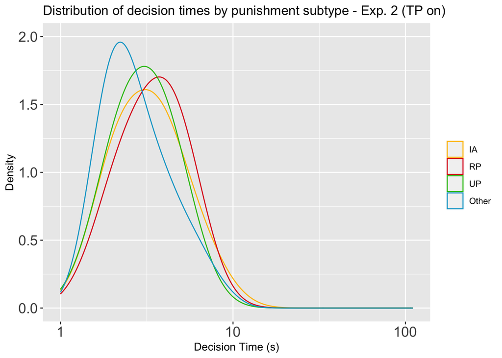

```r
# Create a 4-level variable: 1 = IA, 2 = Reactive, 3 = Unexpl., 4 = Other
# here, we need 2 datasets - one for TP on, one for TP off

tpdata_tpon = tpdata_pc %>%
  filter(tp_on == 1) %>%
  mutate(
    behaviorTime_sec = behaviorTime/1000,
    unexplained_p = ifelse(behavior == "P" & reactive_p == 0 &
                             wealth_inequal == 0, 1, 0),
    pun_type = case_when(behavior == "P" & wealth_inequal == 1 ~ 1,
                         behavior == "P" & reactive_p == 1 ~ 2,
                         behavior == "P" & unexplained_p == 1 ~ 3,
                         TRUE ~ 4))

tpdata_tpoff = tpdata_pc %>%
  filter(tp_on == 0) %>%
  mutate(
    behaviorTime_sec = behaviorTime/1000,
    unexplained_p = ifelse(behavior == "P" & reactive_p == 0 &
                             wealth_inequal == 0, 1, 0),
    pun_type = case_when(behavior == "P" & wealth_inequal == 1 ~ 1,
                         behavior == "P" & reactive_p == 1 ~ 2,
                         behavior == "P" & unexplained_p == 1 ~ 3,
                         TRUE ~ 4))

tpdata_pc = tpdata_pc %>% mutate(
    behaviorTime_sec = behaviorTime/1000,
    unexplained_p = ifelse(behavior == "P" & reactive_p == 0 &
                             wealth_inequal == 0, 1, 0),
    pun_type = case_when(behavior == "P" & wealth_inequal == 1 ~ 1,
                         behavior == "P" & reactive_p == 1 ~ 2,
                         behavior == "P" & unexplained_p == 1 ~ 3,
                         TRUE ~ 4))


# save tpon and tpoff data
# save(tpdata_tpon, file = "~/Documents/Projects/harming_esn/code/exp2/tpdata_tpon.Rdata")
# save(tpdata_tpoff, file = "~/Documents/Projects/harming_esn/code/exp2/tpdata_tpoff.Rdata")
# save(tpdata_pc, file = "~/Documents/Projects/harming_esn/code/exp2/tpdata_pc.Rdata")

# Combined fig. - exp 2 (tp on)
tpdata_tpon %>%
  na.omit() %>%
  ggplot(aes(x = behaviorTime_sec, color = as.factor(pun_type))) +
  geom_density(adjust = 2) +
  scale_x_log10(limits = c(1, 110),breaks = c(1, 10, 100)) +
  scale_y_continuous(limits = c(0, 2)) +
  scale_color_manual(labels = c("IA", "RP", "UP", "Other"),
                     values = c("#FFBF00", "#DE1A1A", "#29BF12", "#00A5CF")) +
    theme(
        axis.text = element_text(size = rel(1.3)),
        legend.position = "right") +
  guides(colour=guide_legend(title = NULL))+
  xlab("Decision Time (s)") +
  ylab("Density") +
  ggtitle("Distribution of decision times by punishment subtype - Exp. 2 (TP on)")
```

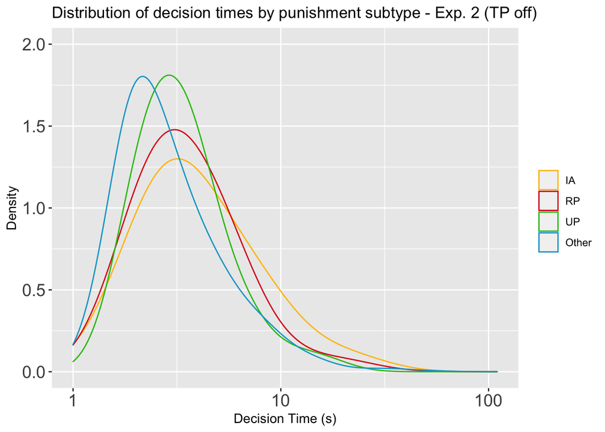

```r
# Combined fig. - exp2 (tp off)
tpdata_tpoff %>%
  na.omit() %>%
  ggplot(aes(x = behaviorTime_sec, color = as.factor(pun_type))) +
  geom_density(adjust = 2) +
  scale_x_log10(limits = c(1, 110),breaks = c(1, 10, 100)) +
  scale_y_continuous(limits = c(0, 2)) +
  scale_color_manual(labels = c("IA", "RP", "UP", "Other"),
                     values = c("#FFBF00", "#DE1A1A", "#29BF12", "#00A5CF")) +
    theme(
        axis.text = element_text(size = rel(1.3)),
        legend.position = "right") +
  guides(colour=guide_legend(title = NULL))+
  xlab("Decision Time (s)") +
  ylab("Density") +
  ggtitle("Distribution of decision times by punishment subtype - Exp. 2 (TP off)")
```

### Punishment subtypes stratified by gender

#### Females only

```r
# All punishment
tpdata_pc %>%
  group_by(tp_on, behavior) %>%
  filter(behavior %in% c("C", "D", "P"),
         gender == "female") %>%
  summarize(n = n()) %>%
  mutate(perc = n/sum(n),
         total = sum(n))
```

```
## # A tibble: 6 × 5
## # Groups:   tp_on [2]
##   tp_on behavior     n  perc total
##   <dbl> <chr>    <int> <dbl> <int>
## 1     0 C          367 0.640   573
## 2     0 D          101 0.176   573
## 3     0 P          105 0.183   573
## 4     1 C          324 0.503   644
## 5     1 D          229 0.356   644
## 6     1 P           91 0.141   644
```

```r
dim(tpdata_pc %>% filter(behavior %in% c("C", "D", "P"), gender == "female"))
```

```
## [1] 1217   61
```

```r
105/573
```

```
## [1] 0.1832461
```

```r
91/644
```

```
## [1] 0.1413043
```

```r
prop.test(c(105, 91), c(573, 644)) #p = 0.056
```

```
##
##  2-sample test for equality of proportions with continuity correction
##
## data:  c(105, 91) out of c(573, 644)
## X-squared = 3.6434, df = 1, p-value = 0.05629
## alternative hypothesis: two.sided
## 95 percent confidence interval:
##  -0.001266414  0.085149865
## sample estimates:
##    prop 1    prop 2
## 0.1832461 0.1413043
```

```r
# IA
tpdata_pc %>%
  group_by(tp_on, behavior, wealth_inequal) %>%
  filter(behavior %in% c("C", "D", "P"),
         is.na(wealth_inequal) == 0,
         gender == "female") %>%
  summarize(n = n()) %>%
  mutate(perc = n/sum(n),
         total = sum(n)) %>%
  filter(wealth_inequal == 1)
```

```
## # A tibble: 6 × 6
## # Groups:   tp_on, behavior [6]
##   tp_on behavior wealth_inequal     n  perc total
##   <dbl> <chr>             <dbl> <int> <dbl> <int>
## 1     0 C                     1   219 0.6     365
## 2     0 D                     1    29 0.29    100
## 3     0 P                     1    65 0.637   102
## 4     1 C                     1   256 0.793   323
## 5     1 D                     1    75 0.328   229
## 6     1 P                     1    63 0.7      90
```

```r
65/573 # tp off
```

```
## [1] 0.113438
```

```r
63/644 # tp on
```

```
## [1] 0.09782609
```

```r
prop.test(c(65, 63), c(573, 644)) # p = 0.428
```

```
##
##  2-sample test for equality of proportions with continuity correction
##
## data:  c(65, 63) out of c(573, 644)
## X-squared = 0.62813, df = 1, p-value = 0.428
## alternative hypothesis: two.sided
## 95 percent confidence interval:
##  -0.02068787  0.05191178
## sample estimates:
##     prop 1     prop 2
## 0.11343805 0.09782609
```

```r
# RP
tpdata_pc %>%
  group_by(tp_on, behavior, reactive_p) %>%
  filter(behavior %in% c("C", "D", "P"),
         is.na(reactive_p) == 0,
         gender == "female") %>%
  summarize(n = n()) %>%
  mutate(perc = n/sum(n),
         total = sum(n)) %>%
  filter(reactive_p == 1)
```

```
## # A tibble: 2 × 6
## # Groups:   tp_on, behavior [2]
##   tp_on behavior reactive_p     n  perc total
##   <dbl> <chr>         <dbl> <int> <dbl> <int>
## 1     0 P                 1    67 0.638   105
## 2     1 P                 1    35 0.385    91
```

```r
67/573 # tp off
```

```
## [1] 0.1169284
```

```r
35/644 # tp on
```

```
## [1] 0.05434783
```

```r
prop.test(c(60, 33), c(573, 644)) # p = 0.00068
```

```
##
##  2-sample test for equality of proportions with continuity correction
##
## data:  c(60, 33) out of c(573, 644)
## X-squared = 11.537, df = 1, p-value = 0.0006823
## alternative hypothesis: two.sided
## 95 percent confidence interval:
##  0.02151419 0.08542542
## sample estimates:
##     prop 1     prop 2
## 0.10471204 0.05124224
```

```r
# UP
tpdata_pc %>%
  group_by(tp_on, behavior, wealth_inequal, reactive_p) %>%
  filter(gender == "female",
         behavior %in% c("C", "D", "P"),
         is.na(wealth_inequal) == 0, is.na(reactive_p) == 0) %>%
  summarize(n = n()) %>%
  mutate(perc = n/sum(n),
         total = sum(n)) %>%
  filter(wealth_inequal == 0 & reactive_p == 0)
```

```
## can override using the `.groups` argument.
```

```
## # A tibble: 6 × 7
## # Groups:   tp_on, behavior, wealth_inequal [6]
##   tp_on behavior wealth_inequal reactive_p     n  perc total
##   <dbl> <chr>             <dbl>      <dbl> <int> <dbl> <int>
## 1     0 C                     0          0   146 1       146
## 2     0 D                     0          0    71 1        71
## 3     0 P                     0          0    18 0.486    37
## 4     1 C                     0          0    67 1        67
## 5     1 D                     0          0   154 1       154
## 6     1 P                     0          0    17 0.630    27
```

```r
18/573 # tp off
```

```
## [1] 0.03141361
```

```r
17/644 # tp on
```

```
## [1] 0.02639752
```

```r
prop.test(c(18, 17), c(573, 644)) # p  = 0.726
```

```
##
##  2-sample test for equality of proportions with continuity correction
##
## data:  c(18, 17) out of c(573, 644)
## X-squared = 0.12307, df = 1, p-value = 0.7257
## alternative hypothesis: two.sided
## 95 percent confidence interval:
##  -0.01553500  0.02556719
## sample estimates:
##     prop 1     prop 2
## 0.03141361 0.02639752
```

```r
# Table 1a - Females only
library(kableExtra)
table1a = tibble(
  pun_type = c("All", "IA", "RP", "UP"),
  tp_off = c(105/573, 65/573, 67/573, 18/573),
  tp_on = c(91/644, 63/644, 35/644, 17/655),
  p = c(0.056, 0.428, 0.001, 0.725)
)

table1a %>%
  kbl(col.names = c("Punish Type", "TP off", "TP on", "p"),
      caption = "Females") %>%
    kable_styling(bootstrap_options = c("striped", "hover", "condensed"))
```

Females

| Punish Type | TP off | TP on | p |
| --- | --- | --- | --- |
| All | 0.1832461 | 0.1413043 | 0.056 |
| IA | 0.1134380 | 0.0978261 | 0.428 |
| RP | 0.1169284 | 0.0543478 | 0.001 |
| UP | 0.0314136 | 0.0259542 | 0.725 |

#### Males only

```r
tpdata_pc %>%
  group_by(tp_on, behavior) %>%
  filter(behavior %in% c("C", "D", "P"),
         gender == "male") %>%
  summarize(n = n()) %>%
  mutate(perc = n/sum(n),
         total = sum(n))
```

```
## # A tibble: 6 × 5
## # Groups:   tp_on [2]
##   tp_on behavior     n  perc total
##   <dbl> <chr>    <int> <dbl> <int>
## 1     0 C          399 0.464   859
## 2     0 D          227 0.264   859
## 3     0 P          233 0.271   859
## 4     1 C          207 0.335   618
## 5     1 D          297 0.481   618
## 6     1 P          114 0.184   618
```

```r
233/859 #tp_off: 0.271
```

```
## [1] 0.2712456
```

```r
114/618 #tp_on: 0.184
```

```
## [1] 0.184466
```

```r
prop.test(c(233, 114), c(859, 618)) #p = 0.00013
```

```
##
##  2-sample test for equality of proportions with continuity correction
##
## data:  c(233, 114) out of c(859, 618)
## X-squared = 14.58, df = 1, p-value = 0.0001343
## alternative hypothesis: two.sided
## 95 percent confidence interval:
##  0.0427375 0.1308217
## sample estimates:
##    prop 1    prop 2
## 0.2712456 0.1844660
```

```r
tpdata_pc %>%
  group_by(tp_on, behavior, wealth_inequal) %>%
  filter(behavior %in% c("C", "D", "P"),
         is.na(wealth_inequal) == 0,
         gender == "male") %>%
  summarize(n = n()) %>%
  mutate(perc = n/sum(n),
         total = sum(n)) %>%
  filter(wealth_inequal == 1)
```

```
## # A tibble: 6 × 6
## # Groups:   tp_on, behavior [6]
##   tp_on behavior wealth_inequal     n  perc total
##   <dbl> <chr>             <dbl> <int> <dbl> <int>
## 1     0 C                     1   286 0.726   394
## 2     0 D                     1    69 0.307   225
## 3     0 P                     1    87 0.382   228
## 4     1 C                     1   158 0.771   205
## 5     1 D                     1   128 0.431   297
## 6     1 P                     1    51 0.451   113
```

```r
87/859 #tp_off: 0.101
```

```
## [1] 0.1012806
```

```r
51/618 #tp_on: 0.083
```

```
## [1] 0.08252427
```

```r
prop.test(c(87, 51), c(859, 618)) #p = 0.258
```

```
##
##  2-sample test for equality of proportions with continuity correction
##
## data:  c(87, 51) out of c(859, 618)
## X-squared = 1.2796, df = 1, p-value = 0.258
## alternative hypothesis: two.sided
## 95 percent confidence interval:
##  -0.01226068  0.04977325
## sample estimates:
##     prop 1     prop 2
## 0.10128056 0.08252427
```

```r
tpdata_pc %>%
  group_by(tp_on, behavior, reactive_p) %>%
  filter(behavior %in% c("C", "D", "P"),
         is.na(reactive_p) == 0,
         gender == "male") %>%
  summarize(n = n()) %>%
  mutate(perc = n/sum(n),
         total = sum(n)) %>%
  filter(reactive_p == 1)
```

```
## # A tibble: 2 × 6
## # Groups:   tp_on, behavior [2]
##   tp_on behavior reactive_p     n  perc total
##   <dbl> <chr>         <dbl> <int> <dbl> <int>
## 1     0 P                 1   109 0.468   233
## 2     1 P                 1    55 0.482   114
```

```r
109/859 #tp_off: 0.127
```

```
## [1] 0.1268917
```

```r
55/618 #tp_on: 0.089
```

```
## [1] 0.08899676
```

```r
prop.test(c(109, 55), c(859, 618)) #p = 0.0276
```

```
##
##  2-sample test for equality of proportions with continuity correction
##
## data:  c(109, 55) out of c(859, 618)
## X-squared = 4.8521, df = 1, p-value = 0.02761
## alternative hypothesis: two.sided
## 95 percent confidence interval:
##  0.004890201 0.070899740
## sample estimates:
##     prop 1     prop 2
## 0.12689173 0.08899676
```

```r
tpdata_pc %>%
  group_by(tp_on, behavior, wealth_inequal, reactive_p) %>%
  filter(gender == "male",
         behavior %in% c("C", "D", "P"),
         is.na(wealth_inequal) == 0, is.na(reactive_p) == 0) %>%
  summarize(n = n()) %>%
  mutate(perc = n/sum(n),
         total = sum(n)) %>%
  filter(wealth_inequal == 0 & reactive_p == 0)
```

```
## can override using the `.groups` argument.
```

```
## # A tibble: 6 × 7
## # Groups:   tp_on, behavior, wealth_inequal [6]
##   tp_on behavior wealth_inequal reactive_p     n  perc total
##   <dbl> <chr>             <dbl>      <dbl> <int> <dbl> <int>
## 1     0 C                     0          0   108 1       108
## 2     0 D                     0          0   156 1       156
## 3     0 P                     0          0    81 0.574   141
## 4     1 C                     0          0    47 1        47
## 5     1 D                     0          0   169 1       169
## 6     1 P                     0          0    36 0.581    62
```

```r
81/859 #tp_off: 0.094
```

```
## [1] 0.09429569
```

```r
36/618 #tp_on: 0.058
```

```
## [1] 0.05825243
```

```r
prop.test(c(81, 36), c(859, 618)) #p = 0.016
```

```
##
##  2-sample test for equality of proportions with continuity correction
##
## data:  c(81, 36) out of c(859, 618)
## X-squared = 5.9169, df = 1, p-value = 0.015
## alternative hypothesis: two.sided
## 95 percent confidence interval:
##  0.007764787 0.064321744
## sample estimates:
##     prop 1     prop 2
## 0.09429569 0.05825243
```

```r
# Table 1b - Males only
table1b = tibble(
  pun_type = c("All", "IA", "RP", "UP"),
  tp_off = c(233/859, 87/859, 109/859, 81/859),
  tp_on = c(114/618, 51/618, 55/618, 36/618),
  p = c(0.00013, 0.258, 0.0276, 0.016)
)

table1b %>%
  kbl(col.names = c("Punish Type", "TP off", "TP on", "p"),
      caption = "Males") %>%
    kable_styling(bootstrap_options = c("striped", "hover", "condensed"))
```

Males

[output not shown]